# Презентация по лабораторной работе №3

Агентное моделирование. Daisyworld

Малюга Валерия Васильевна

1132236050@rudn.ru

Российский университет дружбы народов, Москва, РФ

2026-03-21

## Докладчик

- **Малюга Валерия Васильевна**
- Студент НФИбд-01-23
- Российский университет дружбы народов им. П. Лумумбы
- https://vvmalyuga.github.io/ru/
- 1132236050@rudn.ru

## Цели и задачи

- Познакомиться с **агентным подходом** к имитационному моделированию
- Реализовать модель **Daisyworld** на языке Julia
- Провести **параметрическое исследование** модели
- Создать **литературные скрипты** и сгенерировать производные форматы (чистый код, Jupyter Notebook, Quarto)

## Задание

- Создать рабочий каталог, установить необходимые пакеты
- Выполнить предложенный код
- Преобразовать код в литературный стиль
- Сгенерировать производные форматы
- Интегрировать документацию в отчёт
- Добавить вычисления для набора параметров
- Выложить результаты на GitHub и GitVerse

## Теоретическое введение

### Агентное моделирование

Агентный подход (Agent-Based Modeling, ABM) — это метод исследования сложных систем, в котором поведение системы возникает из взаимодействия множества автономных сущностей (агентов). Вместо глобальных уравнений мы моделируем каждого агента и его правила, а затем наблюдаем коллективные паттерны (Datseris, Vahdati, и DuBois 2022).

### DaisyWorld

Модель Daisyworld предложена Джеймсом Лавлоком и Эндрю Уотсоном для иллюстрации гипотезы Геи (Watson и Lovelock 1983; Wood и др. 2008). В этом мире на клеточной сетке растут чёрные и белые маргаритки, различающиеся альбедо (способностью отражать свет). Чёрные маргаритки поглощают больше тепла, нагревая среду; белые — отражают, охлаждая её. Размножение возможно только в определённом температурном диапазоне. За счёт обратной связи популяции маргариток стабилизируют планетарную температуру.

## Выполнение лабораторной работы

### Создание структуры каталогов

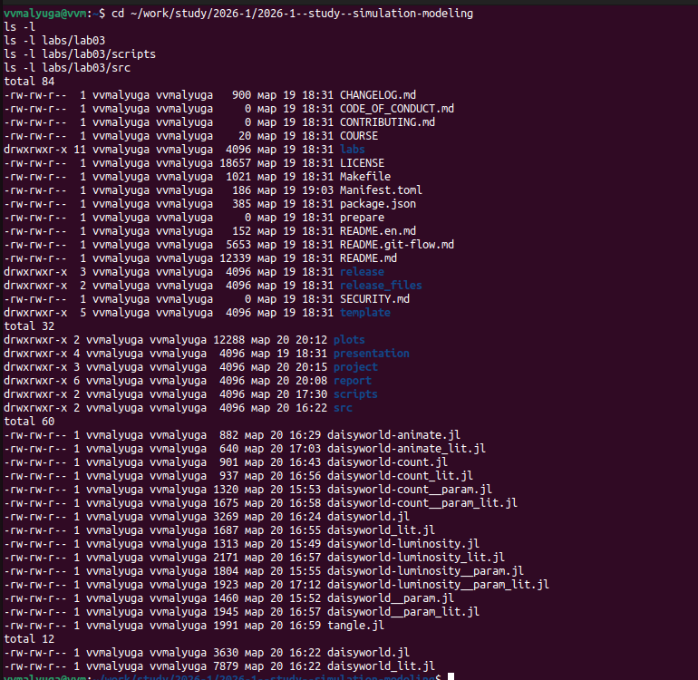

Структура каталогов

## Выполнение лабораторной работы

### Установка пакетов

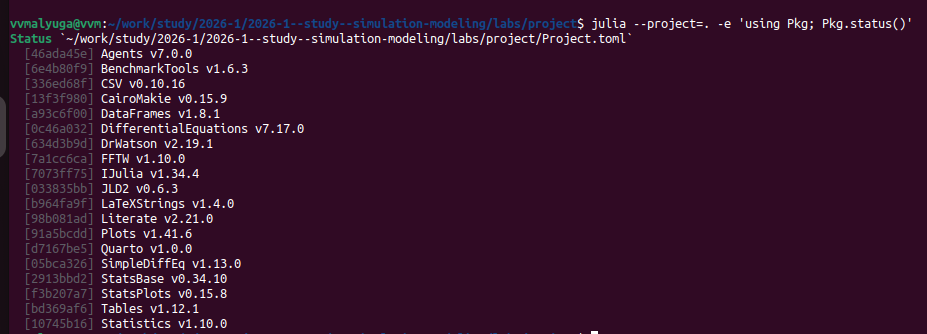

Установленные пакеты

## Выполнение лабораторной работы

### Базовая визуализация

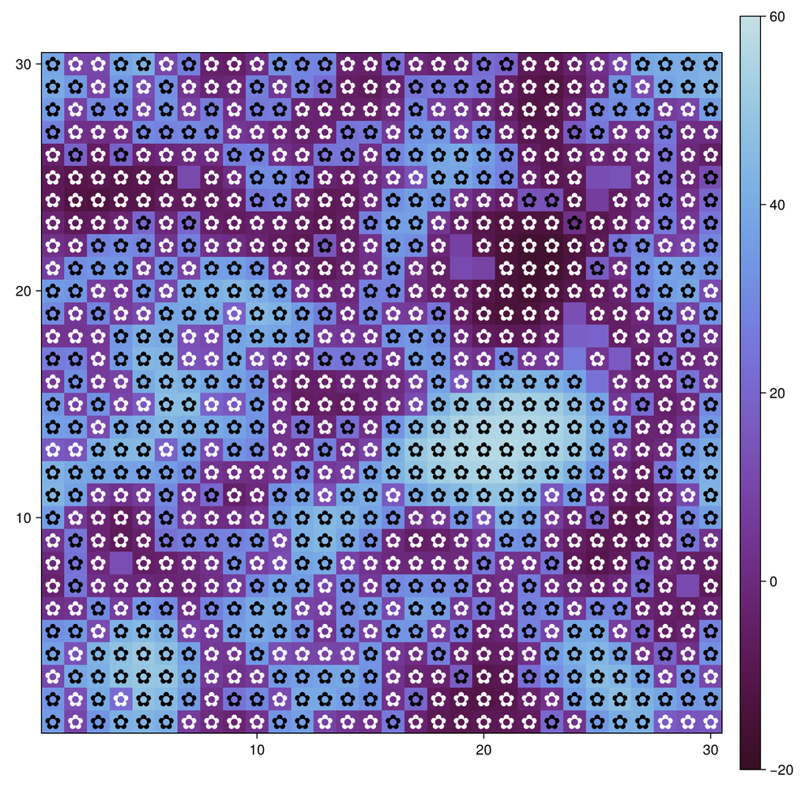

Кадр на шаге 40

## Выполнение лабораторной работы

### Анимация

Скрипт `daisyworld-animate_lit.jl` создаёт видео эволюции модели.

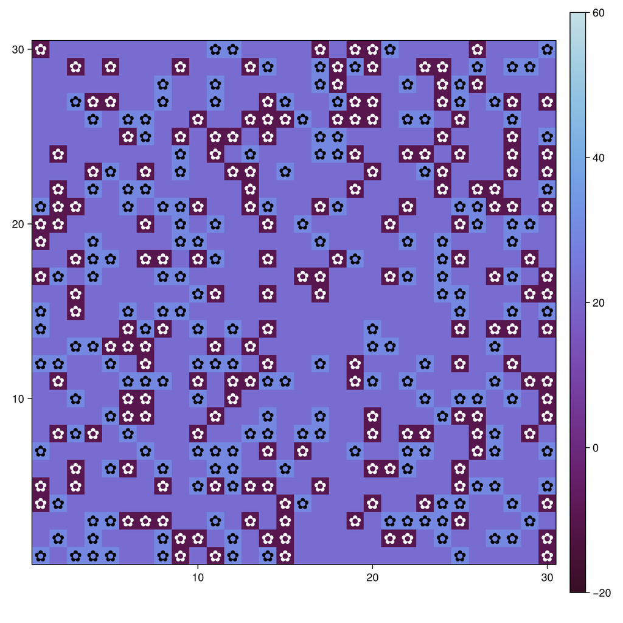

Кадр из анимации

## Выполнение лабораторной работы

### Динамика численности

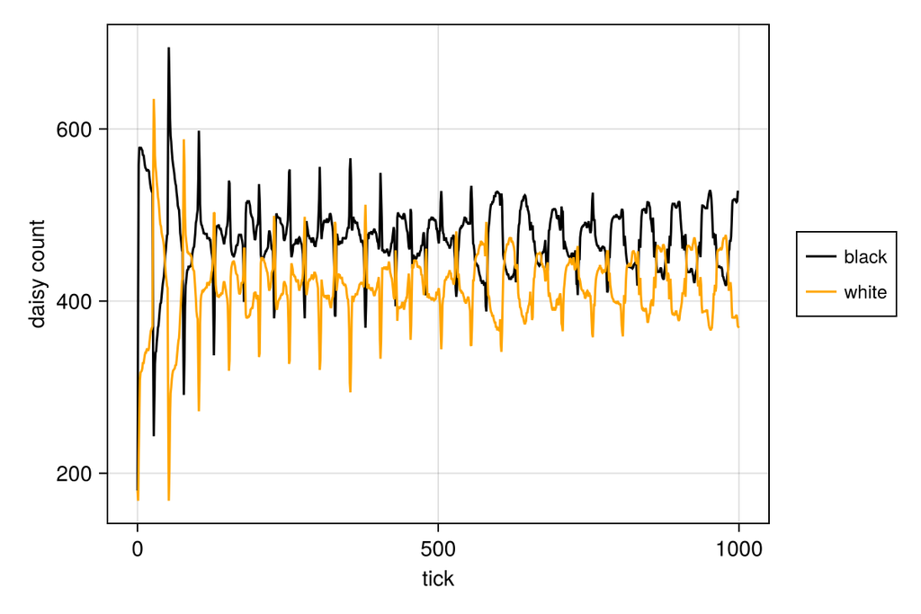

Численность маргариток во времени

## Выполнение лабораторной работы

### Динамика при изменении светимости

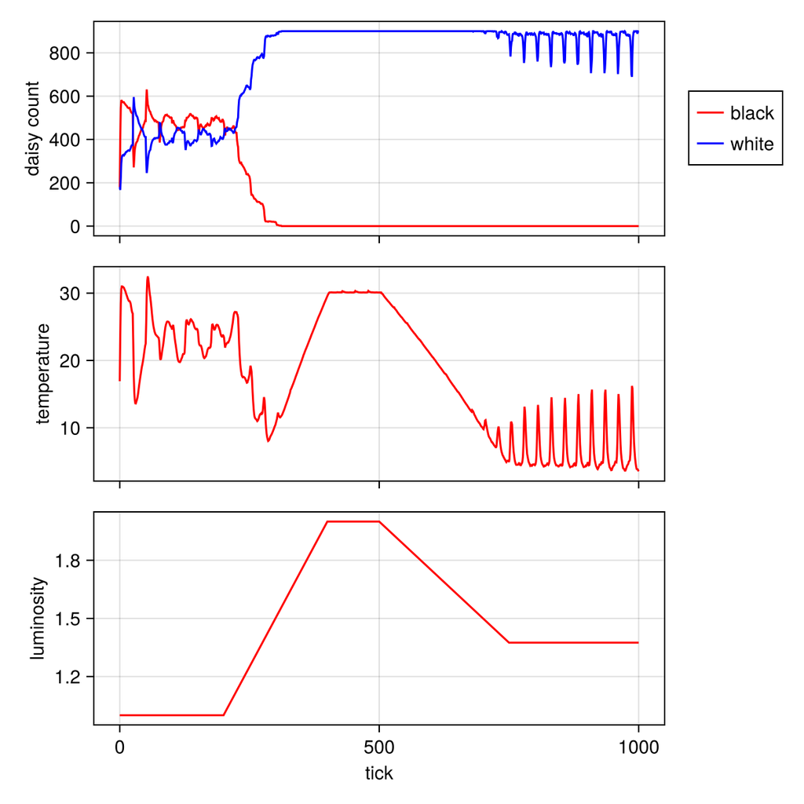

Численность, температура, светимость

## Выполнение лабораторной работы

### Параметрическое исследование

Варьировались `max_age` (25, 40) и `init_white` (0.2, 0.8).

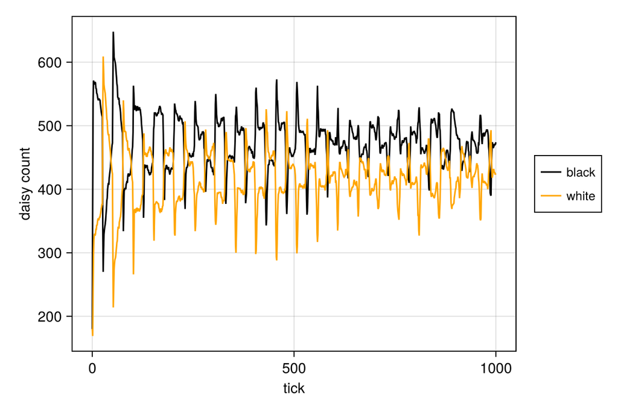

Пример: max_age=25, init_white=0.2

## Выполнение лабораторной работы

### Генерация производных форматов

С помощью `tangle.jl` созданы чистый код, Jupyter Notebook и документы Quarto.

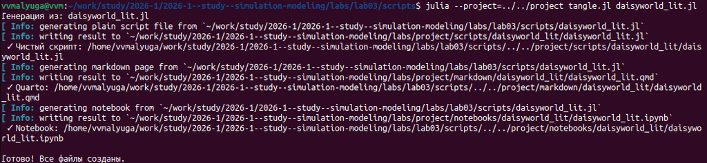

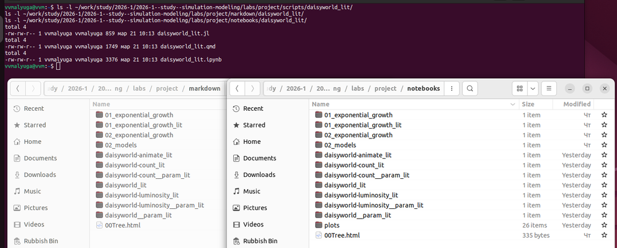

## Результаты модели DaisyWorld

- **Базовая визуализация** подтверждает влияние альбедо на локальную температуру
- **Динамика численности** демонстрирует устойчивые колебания
- **Сценарий `:ramp`** показывает регуляторную способность маргариток
- **Параметрическое исследование** выявило влияние возраста и начальной доли на равновесие

## Выводы

Модель демонстрирует **эмерджентную регуляцию температуры** – обратная связь через альбедо маргариток стабилизирует климат в широком диапазоне параметров.

## Список литературы

Datseris, George, Ali R Vahdati, и Timothy C DuBois. 2022. «Agents.jl: a performant and feature-full agent-based modeling software of minimal code complexity». *SIMULATION* 98 (9): 753–70.

Watson, Andrew J, и James E Lovelock. 1983. «Biological homeostasis of the global environment: the parable of Daisyworld». *Tellus B: Chemical and Physical Meteorology* 35 (4): 284–89.

Wood, Andrew J, Graeme J Ackland, James G Dyke, Hywel TP Williams, и Timothy M Lenton. 2008. «Daisyworld: A review». *Reviews of Geophysics* 46 (1).